# Titanic Fatality Prediction Model

## Introduction

### Purpose:

This notebook is going to explore the Titanic Fatality data provided by Kaggle to determine the best model to predict fatality outcomes based on the feature data documented. This notebook aims to bring a much deeper depth of exploratory knowledge into the predictions, giving hypothetical narratives that are supported by the data that will be processed, explored and modeled.

#### Goal Model:

Our goal model will utilize the Gradient Boosting method using XGBoost to boost the models being produced using the Sckit-Learn library. The Gradient boosting method aims to reduce inherited biases produced by subsequent models while maximizing accuracy rates of the predictions.

```python
import warnings

import pandas as pd
import numpy as npy
import matplotlib.pyplot as mpl
import seaborn as sn
from xgboost import XGBClassifier

print('All standard libraries available, setup successful.')
```

```
All standard libraries available, setup successful.
```

## Data Exploration:

```python
df_train = pd.read_csv("train.csv")
df_test = pd.read_csv("test.csv")
```

#### Summary of the data we are going to be working with to train the model.

```python
df_train.info()
df_train.shape
display(df_train.head())
df_train.tail()
```

```
<class 'pandas.core.frame.DataFrame'>
RangeIndex: 891 entries, 0 to 890
Data columns (total 12 columns):
 #   Column       Non-Null Count  Dtype
---  ------       --------------  -----
 0   PassengerId  891 non-null    int64
 1   Survived     891 non-null    int64
 2   Pclass       891 non-null    int64
 3   Name         891 non-null    object
 4   Sex          891 non-null    object
 5   Age          714 non-null    float64
 6   SibSp        891 non-null    int64
 7   Parch        891 non-null    int64
 8   Ticket       891 non-null    object
 9   Fare         891 non-null    float64
 10  Cabin        204 non-null    object
 11  Embarked     889 non-null    object
dtypes: float64(2), int64(5), object(5)
memory usage: 83.7+ KB
```

|  | PassengerId | Survived | Pclass | Name | Sex | Age | SibSp | Parch | Ticket | Fare | Cabin | Embarked |
| --- | --- | --- | --- | --- | --- | --- | --- | --- | --- | --- | --- | --- |
| 0 | 1 | 0 | 3 | Braund, Mr. Owen Harris | male | 22.0 | 1 | 0 | A/5 21171 | 7.2500 | NaN | S |
| 1 | 2 | 1 | 1 | Cumings, Mrs. John Bradley (Florence Briggs Th... | female | 38.0 | 1 | 0 | PC 17599 | 71.2833 | C85 | C |
| 2 | 3 | 1 | 3 | Heikkinen, Miss. Laina | female | 26.0 | 0 | 0 | STON/O2. 3101282 | 7.9250 | NaN | S |
| 3 | 4 | 1 | 1 | Futrelle, Mrs. Jacques Heath (Lily May Peel) | female | 35.0 | 1 | 0 | 113803 | 53.1000 | C123 | S |
| 4 | 5 | 0 | 3 | Allen, Mr. William Henry | male | 35.0 | 0 | 0 | 373450 | 8.0500 | NaN | S |

|  | PassengerId | Survived | Pclass | Name | Sex | Age | SibSp | Parch | Ticket | Fare | Cabin | Embarked |
| --- | --- | --- | --- | --- | --- | --- | --- | --- | --- | --- | --- | --- |
| 886 | 887 | 0 | 2 | Montvila, Rev. Juozas | male | 27.0 | 0 | 0 | 211536 | 13.00 | NaN | S |
| 887 | 888 | 1 | 1 | Graham, Miss. Margaret Edith | female | 19.0 | 0 | 0 | 112053 | 30.00 | B42 | S |
| 888 | 889 | 0 | 3 | Johnston, Miss. Catherine Helen "Carrie" | female | NaN | 1 | 2 | W./C. 6607 | 23.45 | NaN | S |
| 889 | 890 | 1 | 1 | Behr, Mr. Karl Howell | male | 26.0 | 0 | 0 | 111369 | 30.00 | C148 | C |
| 890 | 891 | 0 | 3 | Dooley, Mr. Patrick | male | 32.0 | 0 | 0 | 370376 | 7.75 | NaN | Q |

It looks like that the sample size is n=891, and there are a total of 10 feature columns. In the "Age", "Cabin" and "Embarked" columns, there are missing values that would need to be imputed during data configuration and sanitization. Names will be normalized for tokenization of key parts of the name, such as title (e.g Mr, Mrs, Miss, etc.) Family names could be utilize to determine an unlabeled aspect of the nodes and may give slight indications to social hiearchy classifications.

### Preprocessing Data Frame:

```python
def preprocess(df):
    df = df.copy()

    def normalize_name(x):
            return " ".join([v.strip(",()[].\"'/") for v in x.split(" ")])
    def name_title(x):
        found_keyword = []
        keywords = {"Mr.", "Mrs.", "Miss.", "Rev.", "Master"}
        for keyword in keywords:
            if keyword in x:
                found_keyword.append(keyword)
                return found_keyword
        else:
            return "NaN"


    def ticket_number(x):
        if x == "LINE":
            return "NaN"
        return x.split(" ")[-1]
    def ticket_item(x):
        items = x.split(" ")
        if len(items) == 1:
            return "NONE"
        return "_".join(items[0:-1])

    df["Title"] = df["Name"].apply(name_title)
    df["Name"] = df["Name"].apply(normalize_name)
    df["Ticket_number"] = df["Ticket"].apply(ticket_number)
    df["Ticket_item"] = df["Ticket"].apply(ticket_item)
    return df.drop("Ticket", axis=1)

preprocessed_train_df = preprocess(df_train)
preprocessed_serving_df = preprocess(df_test)
print("preprocessing completed") #Debugging phrase
```

```
preprocessing completed
```

```python
preprocessed_train_df.info()
display(preprocessed_train_df.head())
display(preprocessed_train_df.tail())
preprocessed_serving_df.head()
```

```
<class 'pandas.core.frame.DataFrame'>
RangeIndex: 891 entries, 0 to 890
Data columns (total 14 columns):
 #   Column         Non-Null Count  Dtype
---  ------         --------------  -----
 0   PassengerId    891 non-null    int64
 1   Survived       891 non-null    int64
 2   Pclass         891 non-null    int64
 3   Name           891 non-null    object
 4   Sex            891 non-null    object
 5   Age            714 non-null    float64
 6   SibSp          891 non-null    int64
 7   Parch          891 non-null    int64
 8   Fare           891 non-null    float64
 9   Cabin          204 non-null    object
 10  Embarked       889 non-null    object
 11  Title          891 non-null    object
 12  Ticket_number  891 non-null    object
 13  Ticket_item    891 non-null    object
dtypes: float64(2), int64(5), object(7)
memory usage: 97.6+ KB
```

|  | PassengerId | Survived | Pclass | Name | Sex | Age | SibSp | Parch | Fare | Cabin | Embarked | Title | Ticket_number | Ticket_item |
| --- | --- | --- | --- | --- | --- | --- | --- | --- | --- | --- | --- | --- | --- | --- |
| 0 | 1 | 0 | 3 | Braund Mr Owen Harris | male | 22.0 | 1 | 0 | 7.2500 | NaN | S | [Mr.] | 21171 | A/5 |
| 1 | 2 | 1 | 1 | Cumings Mrs John Bradley Florence Briggs Thayer | female | 38.0 | 1 | 0 | 71.2833 | C85 | C | [Mrs.] | 17599 | PC |
| 2 | 3 | 1 | 3 | Heikkinen Miss Laina | female | 26.0 | 0 | 0 | 7.9250 | NaN | S | [Miss.] | 3101282 | STON/O2. |
| 3 | 4 | 1 | 1 | Futrelle Mrs Jacques Heath Lily May Peel | female | 35.0 | 1 | 0 | 53.1000 | C123 | S | [Mrs.] | 113803 | NONE |
| 4 | 5 | 0 | 3 | Allen Mr William Henry | male | 35.0 | 0 | 0 | 8.0500 | NaN | S | [Mr.] | 373450 | NONE |

|  | PassengerId | Survived | Pclass | Name | Sex | Age | SibSp | Parch | Fare | Cabin | Embarked | Title | Ticket_number | Ticket_item |
| --- | --- | --- | --- | --- | --- | --- | --- | --- | --- | --- | --- | --- | --- | --- |
| 886 | 887 | 0 | 2 | Montvila Rev Juozas | male | 27.0 | 0 | 0 | 13.00 | NaN | S | [Rev.] | 211536 | NONE |
| 887 | 888 | 1 | 1 | Graham Miss Margaret Edith | female | 19.0 | 0 | 0 | 30.00 | B42 | S | [Miss.] | 112053 | NONE |
| 888 | 889 | 0 | 3 | Johnston Miss Catherine Helen Carrie | female | NaN | 1 | 2 | 23.45 | NaN | S | [Miss.] | 6607 | W./C. |
| 889 | 890 | 1 | 1 | Behr Mr Karl Howell | male | 26.0 | 0 | 0 | 30.00 | C148 | C | [Mr.] | 111369 | NONE |
| 890 | 891 | 0 | 3 | Dooley Mr Patrick | male | 32.0 | 0 | 0 | 7.75 | NaN | Q | [Mr.] | 370376 | NONE |

|  | PassengerId | Pclass | Name | Sex | Age | SibSp | Parch | Fare | Cabin | Embarked | Title | Ticket_number | Ticket_item |
| --- | --- | --- | --- | --- | --- | --- | --- | --- | --- | --- | --- | --- | --- |
| 0 | 892 | 3 | Kelly Mr James | male | 34.5 | 0 | 0 | 7.8292 | NaN | Q | [Mr.] | 330911 | NONE |
| 1 | 893 | 3 | Wilkes Mrs James Ellen Needs | female | 47.0 | 1 | 0 | 7.0000 | NaN | S | [Mrs.] | 363272 | NONE |
| 2 | 894 | 2 | Myles Mr Thomas Francis | male | 62.0 | 0 | 0 | 9.6875 | NaN | Q | [Mr.] | 240276 | NONE |
| 3 | 895 | 3 | Wirz Mr Albert | male | 27.0 | 0 | 0 | 8.6625 | NaN | S | [Mr.] | 315154 | NONE |
| 4 | 896 | 3 | Hirvonen Mrs Alexander Helga E Lindqvist | female | 22.0 | 1 | 1 | 12.2875 | NaN | S | [Mrs.] | 3101298 | NONE |

We now have split up the "Name" feature into more stringent categories. The name normalization might come into play as family names at the time were a label of class and subclass. Titles is a more stringent indicator of class an will possibly have a much more influential part when building the XGBoosted model.

### Exploratory modeling

```
Correlation heatmap of numerical variables:
```

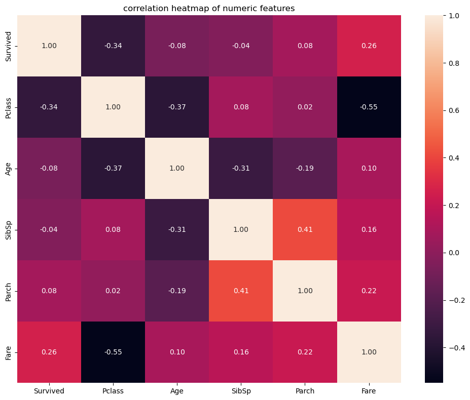

```python
print('Correlation heatmap of numerical variables:')

#Only looking at the numeric or binary values to find outliers and correlations that are of interest for data cleaning and refinement.

#Select for columns with numeric values, those with string values will be omitted.
num_df = preprocessed_train_df.drop("PassengerId", axis = 1).select_dtypes(include=[npy.number])

sn.color_palette("colorblind")

if num_df.shape[1] >= 4:
    mpl.figure(figsize=(10,8))
    sn.heatmap(num_df.corr(), annot=True, fmt='.2f', cmap='rocket')
    mpl.title('correlation heatmap of numeric features')
    mpl.tight_layout()
    mpl.show()
else:
    print('Not enough numeric features for correlation analysis')
```

There is some correlations found between the target variable and the numerical features presented in the data-set, most of them seem to be negative correlations.

##### Survived vs Fare

The single comparatively significant positive correlation is between "Survived" and "Fare" feature. This could slightly indicate that if a passenger had a higher fare price, their survival rate was much higher comparatively to those who had signficantly less costly fares.

##### PClass vs Survived

As seen with Fare vs PClass inverse correlation, the lower class that had lower cost fares were at the upper end of the range of integers being presented for Passenger classes. The law of transitive properties relating PClass with Survived through the Fare vs PClass correlation, the inverse correlation between PCLass and survived, indicates that the lower the passenger class, PClass = 3, the less likely the person is going to be Survived=1 for the Survived category. Sematically, this means that those in the lower class have a lower survival rate as the correlation here presents.

##### Age Distribution Investigation

We are going to take a look at what the "Age" distribution looks like to determine if there are any outliers and/or skews that appear which could affect our overall model performance when taking into account of the feature. If there is a skew in either direction of the age distribution, this can potentially disrupt the accuracy of the model and require more resources to run if it is not appropriately weighted. The libraries being used in this notebook are able to take into account for the inaccuracies, we are only touching upon distribution normality weighing from an educational standpoint. The final model would not have to be directly tabulated to take into account for skewed distributions.

```
count    714.000000
mean      29.699118
std       14.526497
min        0.420000
25%       20.125000
50%       28.000000
75%       38.000000
max       80.000000
Name: Age, dtype: float64
```

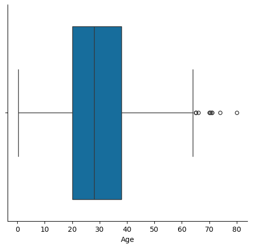

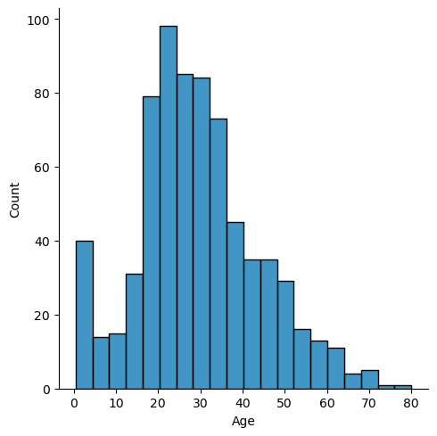

```python
display(preprocessed_train_df["Age"].describe())
sn.set_palette("colorblind")
sn.catplot(data = preprocessed_train_df, x="Age", kind="box")
sn.displot(data = preprocessed_train_df, x="Age")
```

## Data Model

```python
#Tokenize Names for model compatible format.
from sklearn.preprocessing import LabelEncoder
from sklearn.ensemble import RandomForestClassifier
from sklearn.model_selection import StratifiedKFold
from sklearn.metrics import accuracy_score
warnings.filterwarnings('ignore')

cols = ["Name","Title","Pclass","Sex","Cabin","Embarked", "Ticket_item"]
encoder = LabelEncoder()
for col in cols:
    preprocessed_train_df[col] = encoder.fit_transform(preprocessed_train_df[col].astype(str))
    preprocessed_serving_df[col] = encoder.fit_transform(preprocessed_serving_df[col].astype(str))

y_train = preprocessed_train_df["Survived"]
X_train = preprocessed_train_df.drop(["Survived", "PassengerId"], axis=1)

X_test = preprocessed_serving_df.drop('PassengerId', axis = 1)
```

```python
#debug output for Data troubleshooting. Not for Production Use
#ts_output = preprocessed_train_df
#ts_output.to_csv('debug.csv', index=False)
```

```python
#Check for Numpy arrays
X = X_train.values if isinstance(X_train, pd.DataFrame) else X_train
y = y_train.values if isinstance(X_train, pd.Series) else y_train
X_test_npy = X_test.values if isinstance(X_test, pd.DataFrame) else X_test

#Configure Stratified K Fold function for 5-fold cross-validation
kf = StratifiedKFold(n_splits=5, shuffle=True, random_state=42) #Answer to life
test_preds = npy.zeros(len(X_test_npy))
val_scores = []

for fold, (train_idx, val_idx) in enumerate(kf.split(X, y)):
    print(f"Training fold {fold + 1}...")

    X_tr, X_val = X[train_idx], X[val_idx]
    y_tr, y_val = y[train_idx], y[val_idx]

    model = XGBClassifier(n_estimators=100, max_depth=5, learning_rate=0.2, subsample=0.8, colsample_bytree=0.8, tree_method='gpu_hist',
        predictor='gpu_predictor', random_state=42, use_label_encoder=False, eval_metric='logloss')

    model.fit(X_tr, y_tr)

    val_pred = model.predict(X_val)
    val_acc = accuracy_score(y_val, val_pred)
    val_scores.append(val_acc)

    test_preds += model.predict(X_test_npy)

final_preds = (test_preds >= 3).astype(int)

output = pd.DataFrame({'PassengerId': df_test.PassengerId, "Survived": final_preds})
output.to_csv('submission.csv', index=False)

print(f"Your submission was successfully saved! CV Scores: {val_scores}")
print(f"Average CV Accuracy: {npy.mean(val_scores):.4f}")
```

```
Training fold 1...
Training fold 2...
Training fold 3...
Training fold 4...
Training fold 5...
Your submission was successfully saved! CV Scores: [0.8268156424581006, 0.8539325842696629, 0.8033707865168539, 0.848314606741573, 0.8314606741573034]
Average CV Accuracy: 0.8328
```

## Titanic - Machine Learning from Disaster Competition

### Results:

Public Score : 0.74401